# Analyzing MLG distribution

In this document, I will create a graph that shows the distribution of MLGs across populations

```r
library('tidyverse')
library('poppr')
library('igraph')
library("ggraph")
```

## Loading data and setting strata

I’m loading the data and splitting it into the 11 locus and 16 locus versions

```r
load("data/sclerotinia_16_loci.rda")
```

Now we can inspect the genotype accumulation curves. Notice that the 16 loci version plateaus, but we know that these extra loci are inconsistent, so we might not want to trust them.

```r
locus_table(dat)
```

```
allele = Number of observed alleles
1-D = Simpson index
Hexp = Nei's 1978 gene diversity
------------------------------------------
```

```
          summary
locus      allele    1-D   Hexp Evenness
  5-2(F)    4.000  0.451  0.452    0.616
  5-3(F)   12.000  0.839  0.841    0.790
  6-2(F)    3.000  0.643  0.645    0.949
  7-2(F)    7.000  0.727  0.729    0.764
  8-3(H)    7.000  0.740  0.742    0.789
  9-2(F)    9.000  0.347  0.348    0.406
  12-2(H)   5.000  0.579  0.580    0.779
  17-3(H)   7.000  0.551  0.553    0.526
  20-3(F)   2.000  0.053  0.053    0.420
  36-4(F)   4.000  0.255  0.256    0.502
  50-4(F)   3.000  0.257  0.257    0.629
  55-4(F)  10.000  0.721  0.723    0.656
  92-4(F)   9.000  0.796  0.799    0.807
  106-4(H) 32.000  0.918  0.920    0.605
  110-4(H)  5.000  0.754  0.756    0.915
  114-4(H) 10.000  0.828  0.831    0.801
  mean      8.062  0.591  0.593    0.685
```

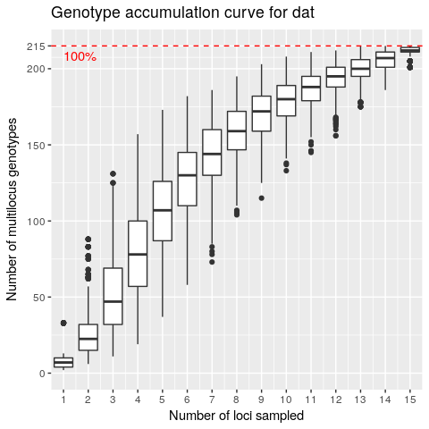

```r
set.seed(2017-06-28)
genotype_curve(dat, sample = 1000, quiet = TRUE)
```

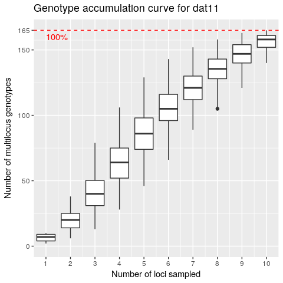

```r
gt16 <- last_plot() +
  theme_bw(base_size = 16, base_family = "Helvetica") +
  stat_smooth() +
  ggtitle("Haplotype accumulation curve for 16 loci") +
  ylab("Number of multilocus haplotypes")
genotype_curve(dat11, sample = 1000, quiet = TRUE)
```

```r
gt11 <- last_plot() +
  theme_bw(base_size = 16, base_family = "Helvetica") +
  stat_smooth() +
  ggtitle("Haplotype accumulation curve for 11 loci") +
  ylab("Number of multilocus haplotypes")
```

```r
if (!interactive()){
  ggsave(gt16,
    filename = "results/figures/publication/genotype-curve16.pdf",
    width = 88*1.66,
    height = 88,
    units = "mm",
    scale = 1)
  ggsave(gt11,
    filename = "results/figures/publication/genotype-curve11.pdf",
    width = 88*1.66,
    height = 88,
    units = "mm",
    scale = 1)
}
```

Creating contracted genotypes for use later

```r
mlg.filter(dat, distance = bruvo.dist, replen = other(dat)$REPLEN) <- .Machine$double.eps
dat
```

```
This is a genclone object
-------------------------
Genotype information:

   187 contracted multilocus genotypes
       (0) [t], (bruvo.dist) [d], (farthest) [a]
   366 haploid individuals
    16 codominant loci

Population information:

     5 strata - MCG, Region, Source, Year, Host
    14 populations defined - NE, NY, MN, ..., France, Mexico, ND
```

```r
mlg.filter(dat11, distance = bruvo.dist, replen = other(dat11)$REPLEN) <- .Machine$double.eps
dat11
```

```
This is a genclone object
-------------------------
Genotype information:

   165 contracted multilocus genotypes
       (0) [t], (bruvo.dist) [d], (farthest) [a]
   366 haploid individuals
    11 codominant loci

Population information:

     5 strata - MCG, Region, Source, Year, Host
    14 populations defined - NE, NY, MN, ..., France, Mexico, ND
```

```r
mll(dat) <- "original"
mll(dat11) <- "original"
```

## Crossing populations

We can use `mlg.crosspop()` to tabulte which MLGs cross populations.

I realized that it’s possible to use an MLG table with matrix multiplication to get an adjency matrix. Here I’m making a function to create a list of graphs.

The edges, representing multilocus genotypes are a bit trickier to handle since multiple edges can represent a single MLG passing through populations. They have the following attributes:

- Label: the MLG this edge belongs to. Note that multiple edges can share the same label.
- Width: the number of populations this MLG passes through
- Weight: 1 - (probability of a second encounter by chance); 1 - psex

The reason why I’m weighting these nodes as 1 - psex is for subsequent community analysis. The more likely you are to encounter a genotype by chance, the less influence that genotype should have on the connectivity.

```r
rerange <- function(x){
  minx <- min(x, na.rm = TRUE)
  maxx <- max(x, na.rm = TRUE)
  if (minx < 0)
    x <- x + abs(minx)
    maxx <- maxx + abs(minx)
  if (maxx > 1)
    x <- x/maxx
  return(x)
}
make_graph_list <- function(dat){ # dat is a genclone/snpclone object
  # w       <- pgen(dat, by_pop = FALSE) %>% rowSums() %>% exp() %>% setNames(paste0("MLG.", mll(dat)))
  # w       <- w[unique(names(w))]
  w       <- psex(dat, by_pop = FALSE, method = "multiple") %>% split(mll(dat))
  names(w)<- paste0("MLG.", names(w))
  datmlg  <- mlg.table(dat, plot = FALSE) > 0 # presence/absence of MLG
  crosses <- mlg.crosspop(dat, quiet = TRUE, df = TRUE) %>% tbl_df()
  adjmat  <- datmlg %*% t(datmlg)
  cols    <- sort(colnames(adjmat))
  adjmat  <- adjmat[cols, cols]
  # Creating Graph
  g           <- graph_from_adjacency_matrix(adjmat, mode = "undirected", diag = FALSE)
  V(g)$size   <- diag(adjmat)
  g           <- delete_vertices(g, degree(g) == 0)
  shared_mlg  <- (crosses %>% group_by(Population) %>% summarize(n = n()))$n
  V(g)$weight <- shared_mlg/V(g)$size # fraction of shared MLGs
  el          <- as_adj_edge_list(g)
  el          <- el[lengths(el) > 0]
  popgraphs <- setNames(vector(mode = "list", length = length(el) + 1), c(names(el), "total"))
  for (v in names(el)){
    idx  <- el[[v]]
    mlgs <- crosses %>%           # How to get all MLGs from a single population:
      filter(Population == v) %>%         # Grab only the population e and then
      select(MLG) %>%                     # remove everything but the MLGs to do an
      inner_join(crosses, by = "MLG") %>% # inner join of the original list and then
      filter(Population != v) %>%         # remove the query population to give
      arrange(Population)                 # the neigboring populations in order.
    MLGS <- as.character(mlgs$MLG)
    E(g)[idx]$label  <- substr(MLGS, 5, nchar(MLGS))
    E(g)[idx]$width  <- as.integer(table(MLGS)[MLGS]) # size == n populations visited
    E(g)[idx]$weight <- 1 - map_dbl(w[MLGS], 2)       # weight == 1 - psex 2nd encounter
    popgraphs[[v]]   <- subgraph.edges(g, eids = idx)
  }
  popgraphs[["total"]] <- g
  popgraphs
}
plot_mlg_graph <- function(g, glayout = NULL, label = TRUE, seed = 2017-06-28){
  set.seed(seed)
  if (is.null(glayout)){
    glayout <- layout_nicely(g)
    colnames(glayout) <- c("x", "y")
  } else {
    glayout <- glayout[V(g)$name, ]
  }
  shared_mlg  <- V(g)$weight * V(g)$size
  g           <- add_vertices(g, length(V(g)), size = V(g)$size - shared_mlg, color = "grey90")
  g2          <- g
  V(g2)$label <- ifelse(!is.na(V(g2)$name), sprintf("%s [(%d/%d)]", V(g2)$name, shared_mlg, V(g2)$size), NA)
  glay        <- create_layout(g2, "manual", node.positions = as.data.frame(rbind(glayout, glayout)))
  x_nudge     <- ifelse(abs(glay$x) == 1, -glay$x/10, glay$x/10)
  breaks      <- quantile(1 - E(g)$weight)
  breaks      <- setNames(breaks, format(breaks, digits = 2))
  outg <- ggraph(glay) +
    geom_edge_fan(aes(alpha = 1 - weight, width = width + 1)) +
    geom_node_circle(aes(r = sqrt(size)/30, fill = size))
  outg <- if (label) outg + geom_node_label(aes(label = label), repel = TRUE, parse = TRUE, label.size = 0.75, nudge_x = x_nudge, segment.size = 0, segment.alpha = 0) else outg
  outg +
    viridis::scale_fill_viridis(option = "C") +
    scale_edge_alpha_continuous(range = c(1, 0.25), breaks = rev(breaks)) +
    scale_edge_width_continuous(range = c(0.25, 1.25), breaks = c(2:5)) +
    coord_fixed() +
    theme_void() +
    theme(text = element_text(size = 14)) +
    labs(list(
     # title = "Shared MLGs across regions",
      fill = "Number of\nMLHs",
      edge_alpha = "Probability of\nsecond encounter",
      edge_width = "Populations\nper MLH"#,
      #caption = "Outer circle: Number of MLGs in the region\nInner Circle: Number of private MLGs in the region"
    ))
}
plot_mlg_subgraph <- function(graphlist){
  for (i in names(graphlist)){
    pg   <- graphlist[[i]]
    labs <- ifelse(E(pg)$width > 1, E(pg)$label, NA)
    labs <- ifelse(duplicated(labs), NA, labs)
    plot(pg,
         main = i,
         layout = layout_as_star(pg, center = i),
         edge.width = E(pg)$width,
         edge.color = grey(rerange(1 - E(pg)$weight)),
         edge.label = labs)
  }
}
good_layout <- read.table(
text =
"   x                            y
Australia  0.8090169943749470071737  5.877852522924730260812e-01
CA -1.0000000000000000000000  1.224646799147350002426e-16
CO -0.3090169943749480063744 -9.510565162951539752711e-01
France -0.3090169943749470071737  9.510565162951539752711e-01
MI  0.0000000000000000000000  0.000000000000000000000e+00
MN  1.0000000000000000000000  0.000000000000000000000e+00
ND  0.3090169943749470071737 -9.510565162951539752711e-01
NE -0.8090169943749470071737 -5.877852522924730260812e-01
NY  0.8090169943749470071737 -5.877852522924730260812e-01
OR  0.3090169943749470071737  9.510565162951539752711e-01
WA -0.8090169943749470071737  5.877852522924730260812e-01"
) %>% as.matrix()
alt_layout <- read.table(
text =
"   x                            y
Australia  0.8090169943749470071737  5.877852522924730260812e-01
OR -1.0000000000000000000000  1.224646799147350002426e-16
CO -0.3090169943749480063744 -9.510565162951539752711e-01
WA -0.3090169943749470071737  9.510565162951539752711e-01
MI  0.0000000000000000000000  0.000000000000000000000e+00
MN  1.0000000000000000000000  0.000000000000000000000e+00
ND  0.3090169943749470071737 -9.510565162951539752711e-01
NE -0.8090169943749470071737 -5.877852522924730260812e-01
NY  0.8090169943749470071737 -5.877852522924730260812e-01
France  0.3090169943749470071737  9.510565162951539752711e-01
CA -0.8090169943749470071737  5.877852522924730260812e-01"
) %>% as.matrix()
alt_layout <- alt_layout[rownames(good_layout), ]
```

## Graphs

With the fuctions above, we can create and plot the graphs.

```r
# Creating the graphs
graph16loc <- make_graph_list(dat)
graph11loc <- make_graph_list(dat[loc = keeploci, mlg.reset = TRUE])
```

## Graph legend

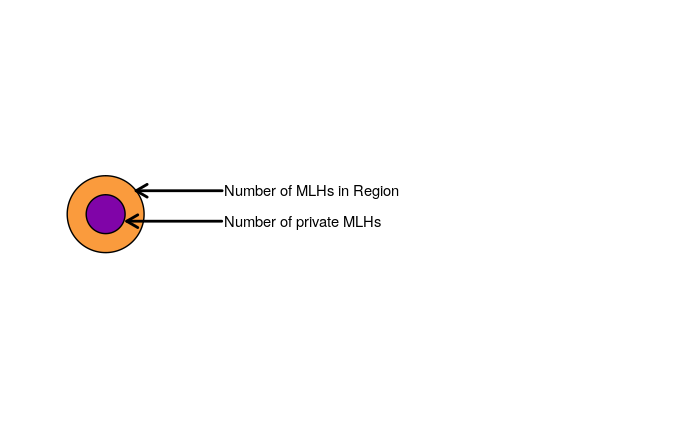

```r
g <- graph_from_adjacency_matrix(matrix(0, 2, 2))
V(g)$size <- c(43, 43 - 32)
V(g)$label <- c("Number of MLHs in Region", "Number of private MLHs")
lay <- as.data.frame(matrix(0, 2, 2, dimnames = list(NULL, c("x", "y"))))
glegend <- create_layout(g, "manual", node.positions = as.data.frame(lay)) %>% ggraph() +
  geom_node_circle(aes(r = sqrt(size)*5, fill = size)) +
  coord_fixed() +
  viridis::scale_fill_viridis(option = "C", begin = 1 - 32/43, end = 43/56, guide = "none") +
  ggrepel::geom_text_repel(aes(label = label),
                           x = c(6, -2) + 20,
                           y = c(20, -6),
                           nudge_x = 150,
                           segment.size = 1,
                           arrow = arrow(length = unit(0.15, "native")),
                           family = "Helvetica") +
  theme_void() +
  # theme(plot.background = element_rect(color = "black", fill = "grey98")) +
  xlim(c(-60, 480))

glegend
```

### Individual population subgraphs

Each subgraph shows all of the connections for a single population.

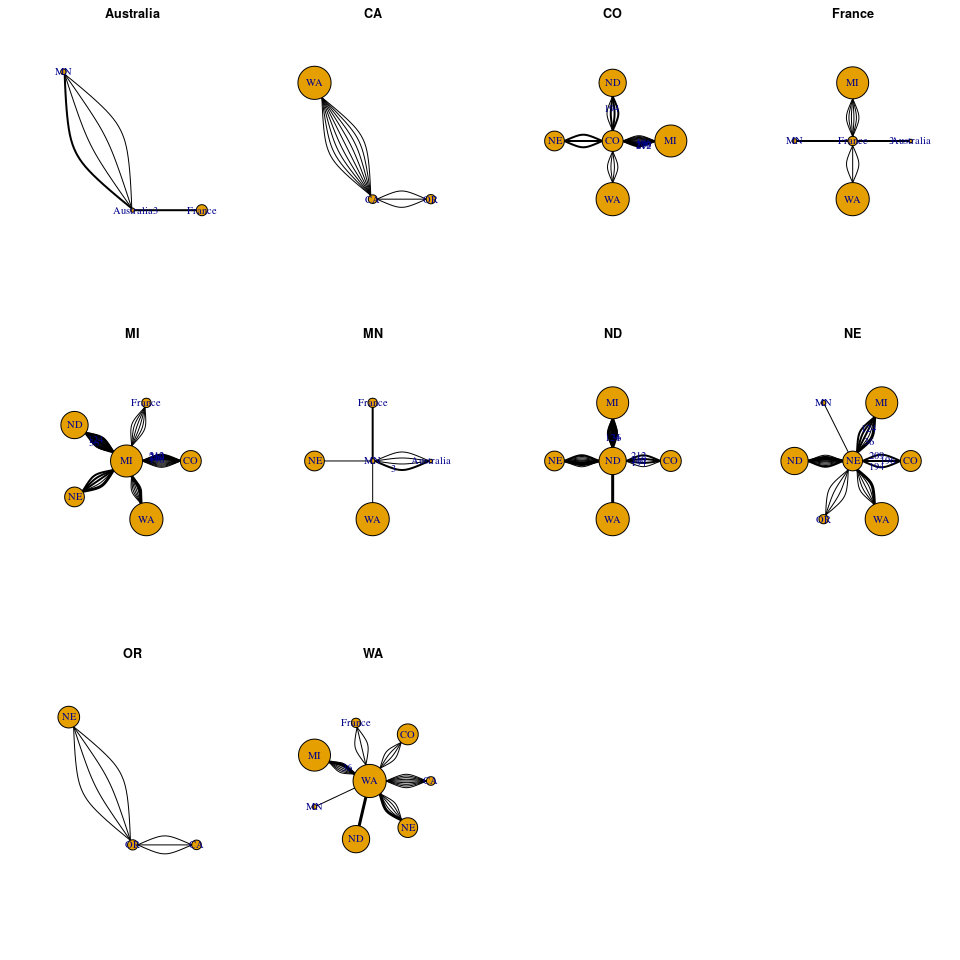

```r
# Plotting the subgraphs
par(mfrow = c(3, 4))
plot_mlg_subgraph(graph16loc[-length(graph16loc)])
par(mfrow = c(3, 4))
```

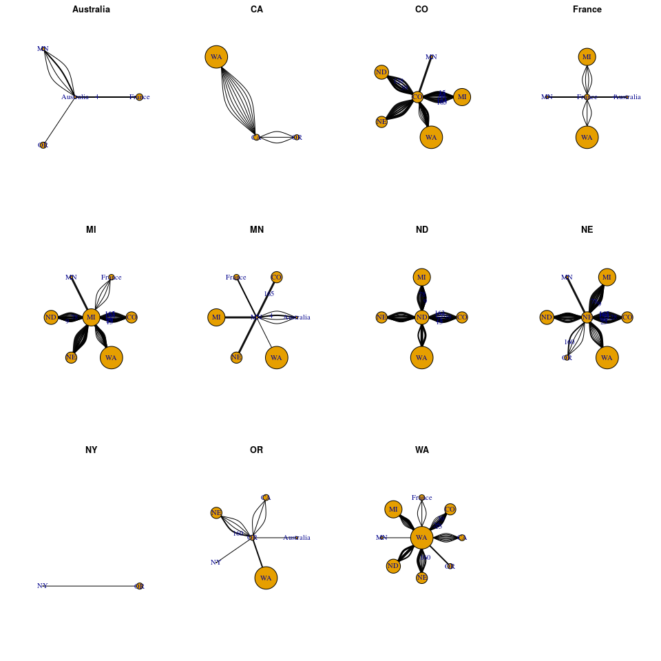

```r
plot_mlg_subgraph(graph11loc[-length(graph11loc)])
```

### Cross-regional graphs

I’m plotting two graphs here because it’s useful to see if both of them are congruent in their community predictions.

#### With 16 loci

First, I’m going to show the results of a community analysis. I’m using the igraph function `cluster_optimal()` to cluster the nodes.

```r
par(mfrow = c(1, 1))
(g16o <- cluster_optimal(graph16loc$total))
```

```
IGRAPH clustering optimal, groups: 3, mod: 0.2
+ groups:
  $`1`
  [1] "Australia" "France"    "MN"

  $`2`
  [1] "CA" "OR" "WA"

  $`3`
  [1] "CO" "MI" "ND" "NE"
```

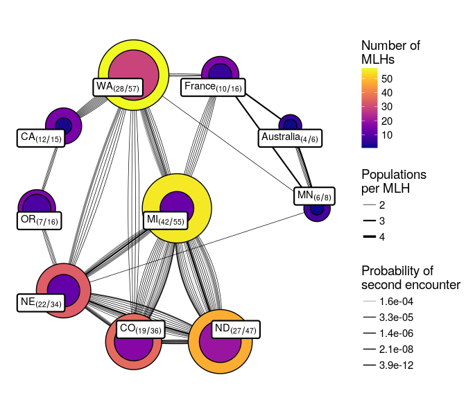

```r
gg16 <- plot_mlg_graph(graph16loc$total, alt_layout) #+ labs(list(subtitle = "(16 loci)"))
gg16
```

```r
ggsave(filename = "results/figures/publication/FigureS1Z.pdf", width = 88, height = (6.25/7)*88, units = "mm", scale = 2)
```

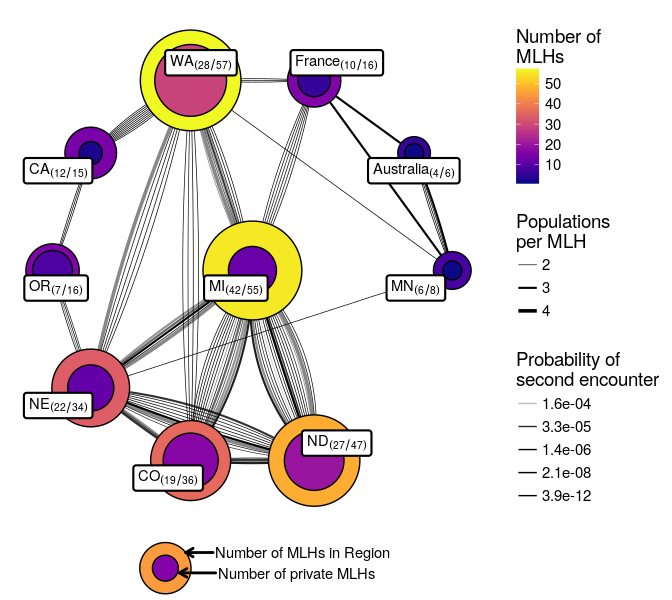

```r
suppressWarnings(
  gg16cp <- cowplot::ggdraw(xlim = c(0, 1), ylim = c(0, 1)) +
  cowplot::draw_plot(gg16, x = 0, y = 0.05) +
  cowplot::draw_plot(glegend, x = -0.0125, y = 0, height = 0.1)
  )
gg16cp
```

```r
cowplot::ggsave(plot = gg16cp,
                file = file.path(PROJHOME, "results", "figures", "publication", "mlg-16.pdf"),
                width = 88,
                height = (6.25/7)*88,
                units = "mm",
                scale = 2)
```

What we see is that We are given three clusters showing a clustering of the plains states, the west coast, and Australia, France, and Minnesota. The last cluster is likely driven by the single genotype shared between these three regions that has a low probability of a second encounter.

#### With 11 loci

```r
(g11o <- cluster_optimal(graph11loc$total))
```

```
IGRAPH clustering optimal, groups: 3, mod: 0.17
+ groups:
  $`1`
  [1] "Australia" "France"    "MN"

  $`2`
  [1] "CA" "NY" "OR" "WA"

  $`3`
  [1] "CO" "MI" "ND" "NE"
```

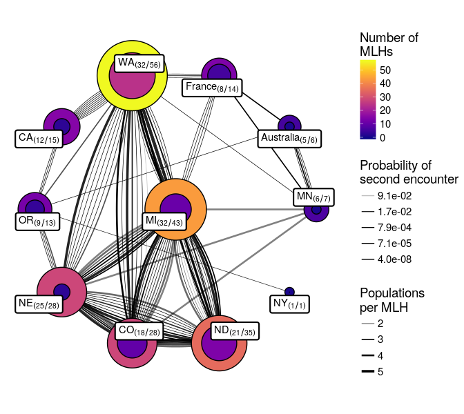

```r
gg11 <- plot_mlg_graph(graph11loc$total, alt_layout)
gg11
```

```r
ggsave(filename = "results/figures/publication/Figure3Z.pdf", width = 88, height = (6.25/7)*88, units = "mm", scale = 2)
```

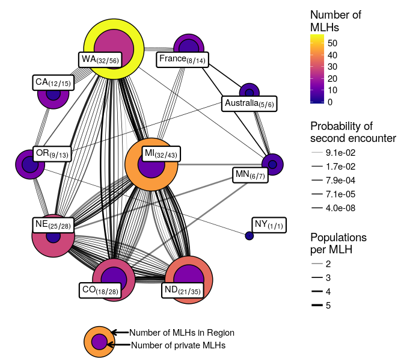

```r
suppressWarnings(
  gg11cp <- cowplot::ggdraw(xlim = c(0, 1), ylim = c(0, 1)) +
  cowplot::draw_plot(gg11, x = 0, y = 0.05) +
  cowplot::draw_plot(glegend, x = -0.0125, y = 0, height = 0.1)
  )
gg11cp
```

```r
cowplot::ggsave(plot = gg11cp,
                file = file.path(PROJHOME, "results", "figures", "publication", "mlg-11.pdf"),
                width = 88,
                height = (6.25/7)*88,
                units = "mm",
                scale = 2)
```

```r
save(graph16loc, graph11loc, alt_layout, file = "data/mlg-crosspop-graph.rda")
```

### Region Cohesion

Here I am using DAPC to assess how cohesive these artificial regions are.

```r
g11o <- igraph::cluster_optimal(graph11loc$total)
comm <- igraph::communities(g11o)
names(comm) <- c("International", "Costal", "Midwest")
comm
strata(dat11) <- strata(dat11) %>%
  mutate(MLGRegion = case_when(
    .$Region %in% comm$International ~ "International",
    .$Region %in% comm$Costal ~ "Costal",
    .$Region %in% comm$Midwest ~ "Midwest",
    TRUE ~ as.character(.$Region)
  ))

setPop(dat11) <- ~MLGRegion
```

```
1 group has only 1 member so it cannot be represented in both training and validation sets.
```

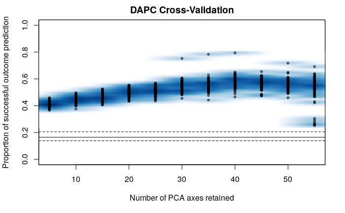

```r
set.seed(2017-07-12)
reg <- xvalDapc(tab(dat11), pop(dat11), n.rep = 100)
```

```r
reg$DAPC
```

```
    #################################################
    # Discriminant Analysis of Principal Components #
    #################################################
class: dapc
$call: dapc.data.frame(x = as.data.frame(x), grp = ..1, n.pca = ..2,
    n.da = ..3)

$n.pca: 40 first PCs of PCA used
$n.da: 5 discriminant functions saved
$var (proportion of conserved variance): 0.985

$eig (eigenvalues): 681.7 62.45 58.11 13.78 8.412  vector    length content
1 $eig      5      eigenvalues
2 $grp      366    prior group assignment
3 $prior    6      prior group probabilities
4 $assign   366    posterior group assignment
5 $pca.cent 69     centring vector of PCA
6 $pca.norm 69     scaling vector of PCA
7 $pca.eig  58     eigenvalues of PCA

  data.frame    nrow ncol content
1 $tab          366  40   retained PCs of PCA
2 $means        6    40   group means
3 $loadings     40   5    loadings of variables
4 $ind.coord    366  5    coordinates of individuals (principal components)
5 $grp.coord    6    5    coordinates of groups
6 $posterior    366  6    posterior membership probabilities
7 $pca.loadings 69   40   PCA loadings of original variables
8 $var.contr    69   5    contribution of original variables
```

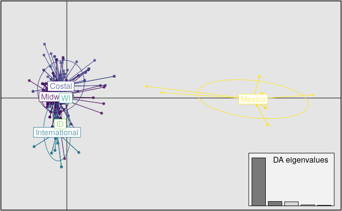

```r
scatter(reg$DAPC, col = viridis::viridis(6), bg = "grey90")
```

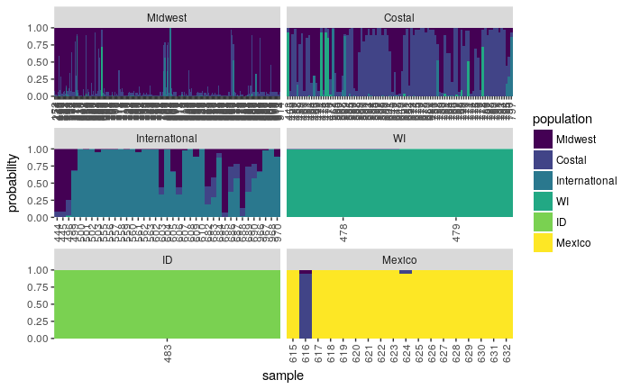

```r
ggcompoplot::ggcompoplot(reg$DAPC, dat11, pal = viridis::viridis(6), cols = 2)
```

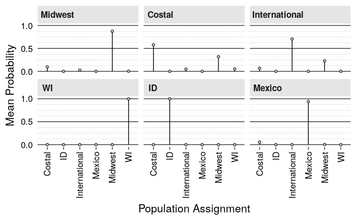

```r
reg$DAPC$posterior %>%
  as_tibble() %>%
  bind_cols(data.frame(Population = reg$DAPC$grp)) %>%
  group_by(Population) %>%
  summarize_all(mean) %>%
  gather(assignment, probability, -Population) %>%
  ggplot(aes(x = assignment, y = probability)) +
  geom_segment(aes(xend = assignment, yend = 0)) +
  geom_point(pch = 21, fill = "grey") +
  facet_wrap(~Population) +
  scale_y_continuous(limits = c(0, 1),
                     minor_breaks = c(seq(0, 1, by = 0.125)),
                     breaks = c(0, 0.5, 1)) +
  theme_bw(base_size = 16, base_family = "Helvetica") +
  theme(legend.position = "top") +
  theme(aspect.ratio = 1/2) +
  theme(axis.text = element_text(color = "black")) +
  theme(axis.ticks.y = element_blank()) +
  theme(axis.text.x = element_text(angle = 90, vjust = 0.5, hjust = 1)) +
  theme(panel.grid.major.x = element_line(linetype = 0, color = "grey50")) +
  theme(panel.grid.major = element_line(colour = "grey20")) +
  theme(panel.grid.minor = element_line(linetype = 3, colour = "grey50")) +
  theme(strip.background = element_rect(color = NA, fill = "grey90")) +
  theme(strip.text = element_text(face = "bold", hjust = 0.05)) +
  theme(panel.border = element_blank()) +
  xlab("Population Assignment") +
  ylab("Mean Probability")
```